# Final Project: Crime Prediction Model

Srujana Bhoopanam

May 7th, 2019

#### An analysis to predict future crimes from the hisorical crime data to stop them!

# 1. SCOPING

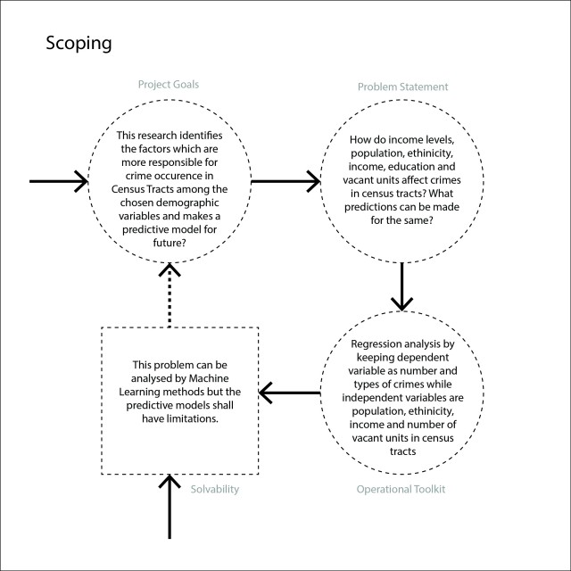

## 1.1. Aim

This project’s aim is to construct an accurate regression prediction model for crime occurence in New York City and thereby help the “Mayor’s Office of Criminal Justice” to strategize how to use its resources efficiently.The number of crimes(dependent variable) occuring in a census tract are predicted on the basis of independent variable information of census tract which is collected from ACS Data :

1. race segregation
2. population
3. Unemployment rate
4. number vacant units
5. median household income
6. Total population that has less than high school education percentage

## 1.2 Research Questions

### What predictive methodologies can be adopted to predict crime?

# 2. DATA

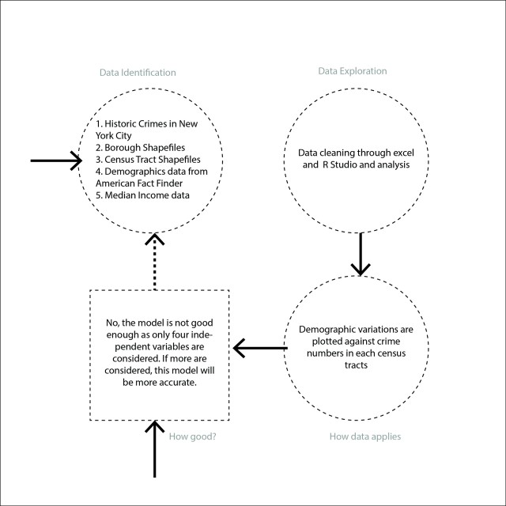

## 2.1. Data Sources

The following data is collected from New York Police Department, Open Data and American Community Survey respectively : 1) NYPD’s Historic Complaint Data is colleted from https://data.cityofnewyork.us/Public-Safety/NYPD-Complaint-Data-Historic/qgea-i56i 2) NYC Boroughs from NYC Open data : https://data.cityofnewyork.us/City-Government/Borough-Boundaries/tqmj-j8zm 3) NYC Census Tracts from NYC Open Data : https://data.cityofnewyork.us/City-Government/2010-Census-Tracts/fxpq-c8ku 4) ACS(American Community Survey) Data for race distribution, population, population per acre, unemployment rates, vacant units, median household income, number of vacant units, total population that has less than high shool education percentage of census tracts.

## 2.2. Data Preparation

This section shows how the data was cleaned.

### 2.2.1 ACS Data Preparation

As there are only about 2160 census tracts in the city, some of the ACS data was processed in microsoft excel while historical crime data was processed in R Studio. Throughout the data cleaning process, some steps were taken to make a model that was more efficient. These are:

1. Only census tracts with non-zero populations were considered
2. The independent variables that had “NULL” entries were not considered to be a part of the final model.
3. The Unemployment rate and less than high school education percentage data had “NA” entries in their columns. These were also not considered.

```r
library("readxl")
library(dplyr)


Population<-read_excel("Population_CT.xlsx")
head(Population)
#View (Population)
PopulationsDF<- Population %>% dplyr::select (`Borough`, `2010 DCP Borough Code`, `2010 Census Tract`, `2010`, `2010 Persons Per Acre`)

names(PopulationsDF)<-c("Borough", "2010_borough_code", "2010_census_tract", "2010_Pop", "2010_persons_per_acre")
#View (PopulationsDF)
#considering only the census tracts with nonzero population
PopulationsDF<-PopulationsDF[PopulationsDF$`2010_Pop`!=0,]
View (PopulationsDF)
write.csv(PopulationsDF, file = "NYC_Census_Tract_2010_pop.csv")


#Reading racedistribution file
RaceDistribution<-read_excel("RaceDistribution_CT.xlsx")
head(RaceDistribution)
RacesDF <- RaceDistribution %>% dplyr::select (`Borough`, `2010 DCP Borough Code`, `2010 Census Tract`, `Total Population`, `White`, `Black/ African American`,
                                               `American Indian and Alaska Native`, `Asian`, `Native Hawaiian and Other Pacific Islander`,
                                               `Some Other Race`, `Two or More Races`, `Hispanic Origin (of any race)` )

names(RacesDF)<-c("Borough", "boro_code", "boro_ct_2010", "2010_Pop", "white", "African American", "AI and Alaska", "Asian", "Hawai", "Some other Race", "Two or More", "Hispanic")
#considering only the census tracts with nonzero population
RacesDF<-RacesDF[RacesDF$`2010_Pop`!=0,]


View (RacesDF)
write.csv(RacesDF, file = "NYC_Race_Distribution.csv")

VacantUnits<-read_excel("VacantUnits_CT.xlsx")
View (VacantUnits)

VacantDF <- VacantUnits %>% dplyr::select (`Borough`, `2010 DCP Borough Code`, `2010 Census Tract`, `Total Housing Units`, `Occupied Housing Units`, `Vacant Housing Units`)
names(VacantDF)<-c("Borough", "boro_code", "boro_ct_2010", "Total", "occupied", "Vacant")

write.csv(VacantDF, file = "Vacant_Housing.csv")


#Read the median income excel sheet, clean it and write the results to csv file
Income<- read_excel("Median_Income_CT.xlsx")
#head(Income)
IncomeDF <- Income %>% dplyr::select (`boro_code`, `ct2010_lon`, `boro_name`, `MHI` )
head(IncomeDF)
names(IncomeDF)<-c("boro_code", "boro_ct_2010", "boro_name", "MHI")
write.csv(IncomeDF, file = "income_distribution.csv")

#Read the eduction excel sheet, clean it and write the results to csv file
Education<-read_excel("Unemployment_Education_cT.xlsx")
EducationDF <- Education %>% dplyr::select (`tractnum`, `boro_code`, `Unemployment_Rate`, `Total_Less_Than_high_School_Percentage`)
names (EducationDF) <- c("boro_ct_2010", "boro_code", "URate", "HSPer")
#Remove entries with Null values
EducationDF$URate <- as.numeric(as.character(EducationDF$URate))
EducationDF$HSPer <- as.numeric(as.character(EducationDF$HSPer))
#View(EducationDF)
#Take out census tracts with NA values in URate or HSPer
EducationDF<-na.omit(EducationDF)
View(EducationDF)
write.csv(EducationDF, file = "education_distribution.csv")
```

### 2.2.2 NYPD’s Historical Data Preparation

The crimes in the year were joined with census tract shapefile to visually understand where most crimes happened.

Finally, the independent variables were then joined to this as well.

The final section of this was also to divide the crime data as test(30%) data set and train(70%) data set. This is done so to estimate the performance of the model that was created.

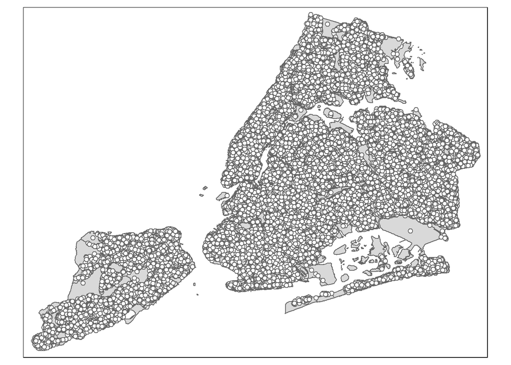

```r
library(dplyr)
library(readr)
library(lubridate)
library(stringr)
library(ggplot2)
library(sf)
library(raster)
library(tmap)

## here we are going to find the root_file
root <- rprojroot::find_rstudio_root_file()
## we are going to set the data file path here
dataDir <- file.path(root, '2010_CT')

#Since this file is too big, run this command only once
Complaints <- read.csv(file="NYPD_Complaint_Data_Historic.csv", header=TRUE, sep=",")
summary(Complaints)
head(Complaints)

ComplaintsDF<- Complaints %>% dplyr::select (`ADDR_PCT_CD`, `BORO_NM`, `CMPLNT_FR_DT`, `CRM_ATPT_CPTD_CD`, `LAW_CAT_CD`,
                         `OFNS_DESC`, `PD_DESC`, `PREM_TYP_DESC`, `RPT_DT`, `Latitude`, `Longitude`)

#Only those crimes are considered which are completed
ComplaintsDF<-ComplaintsDF[ComplaintsDF$CRM_ATPT_CPTD_CD=='COMPLETED',]


names(ComplaintsDF)<-c("Precinct","Borough", "Occurence_Date",
                       "Crime_Status","Offense_Level","Description","Detailed_Description",
                       "Premise","Reporting_Date","Latitude", "Longitude")


ComplaintsDF <- ComplaintsDF %>% mutate(date = lubridate::mdy(ComplaintsDF$Reporting_Date),
                                 year = lubridate::year(date)) %>% filter (year==2010)  %>% filter (`Borough` != "") %>% filter(`Detailed_Description` !="FALSE REPORT UNCLASSIFIED")


View(ComplaintsDF)

summary (ComplaintsDF)
#write.csv(ComplaintsDF, file = "NYPD_Complaints_2010.csv")
#write.csv(Months_first_11, file = "NYPD_Complaints_2010_first_11.csv")
#write.csv(Months_12, file = "NYPD_Complaints_2010_12.csv")

#file.exists
CT <- read_sf(file.path(dataDir, "CT.shp"))
st_crs(CT)

st_crs(CT) <- 2263
#plot(CT)

ComplaintsDF
Cmp_Points <- st_as_sf(ComplaintsDF, coords = c("Longitude", "Latitude"),crs = 2263)
library(tmap)
Cmp_Points
#CT_Jn<-merge(Cmp_Points, CT, key= "coords")
Joined<-st_join(Cmp_Points, CT)
tm_shape(CT)+tm_polygons()+tm_shape(Joined)+tm_symbols(size = 0.2, col="white")
```

```r
print(Joined)

## Conversion back to dataframe as "Joined" is a shapefile that is formed
st_geometry(Joined) <- NULL
#tm_shape(CT) + tm_polygons(col = "white")+
  #tm_shape(Joined) + tm_symbols(size = .2, col = "boro_name",
                                  #alpha = 0.4)

#write.csv(Joined, file = "NYPD_Complaints_2010_JOined_with_shpCT.csv")
Joined<- Joined %>% dplyr::select (`Borough`, `Occurence_Date`, `Offense_Level`, `Detailed_Description`, `Premise`, `Reporting_Date`, `boro_name`, `boro_code`, `ct2010`)
names(Joined)<-c("Borough", "Occurence_Date", "Offense_Level", "Detailed_Description", "Premise", "Reporting_Date", "boro_name", "boro_code", "boro_ct_2010")

##Only those complaints are considered whih are committed and complained in the same borough to reduce ambiguity.
Joined <- Joined %>% filter (str_to_upper (Borough) == str_to_upper(boro_name))

##Counting number of crimes in each sence tract
Joined <- dplyr::summarise(dplyr::group_by(Joined,Joined$boro_code, Joined$boro_ct_2010),count =n())
names(Joined)<-c("boro_code", "boro_ct_2010", "Crime_num")


popDF <- read_csv ("NYC_Census_Tract_2010_pop.csv")
raceDF <- read_csv ("NYC_Race_Distribution.csv")
vacantDF <- read_csv ("Vacant_Housing.csv")
incomeDF <- read_csv ("income_distribution.csv")
educationDF <- read_csv ("education_distribution.csv")

Joined$boro_ct_2010 <- as.numeric(as.character(Joined$boro_ct_2010))
View (popDF)


raceDF$boro_ct_2010 <- as.numeric(as.character(raceDF$boro_ct_2010))
vacantDF$boro_ct_2010 <- as.numeric(as.character(vacantDF$boro_ct_2010))
incomeDF$boro_ct_2010 <- as.numeric(as.character(incomeDF$boro_ct_2010))
educationDF$boro_ct_2010 <- as.numeric(as.character(educationDF$boro_ct_2010))


names(popDF)<-c("index", "Borough", "boro_code", "boro_ct_2010", "2010_Pop", "2010_persons_per_acre")

popDF$boro_ct_2010 <- as.numeric(as.character(popDF$boro_ct_2010))
popDF$boro_code <- as.numeric(as.character(popDF$boro_code))
#View (popDF)


#View (popDF)
Joined <- merge (Joined, popDF, by = c ("boro_code", "boro_ct_2010"))

Joined <- merge (Joined, raceDF, by = c ("boro_code", "boro_ct_2010"))
Joined <- merge (Joined, vacantDF, by = c ("boro_code", "boro_ct_2010"))
Joined <- merge (Joined, incomeDF, by = c ("boro_code", "boro_ct_2010"))
Joined <- merge (Joined, educationDF, by = c ("boro_code", "boro_ct_2010"))


# Removes duplicated Columns
Joined <- Joined[, !duplicated(colnames(Joined))]
Joined <- Joined %>% dplyr::select(`boro_code`, `boro_ct_2010`, `Crime_num`, `2010_Pop.x`, `2010_persons_per_acre`, `Borough.x`, `white`, `African American`, `AI and Alaska`,
                                 `Asian`, `Hawai`, `Some other Race` , `Two or More`, `Hispanic`, `Total`, `occupied`, `Vacant`, `MHI`, `URate`, `HSPer`
)
View(Joined)

# splitting as test and train
library (rsample)
set.seed (123)
crime_split <- initial_split(Joined, prop = .7)
Months_first_11 <- training (crime_split)
Months_12 <- testing (crime_split)

View (Months_first_11)
View (Months_12)
nrow(Months_first_11)
nrow(Months_12)

#write.csv(Months_first_11, file = "TrainDatafinal_Final.csv")
#write.csv(Months_12, file = "TestDatafinal_Final.csv")
```

# 3. Analysis

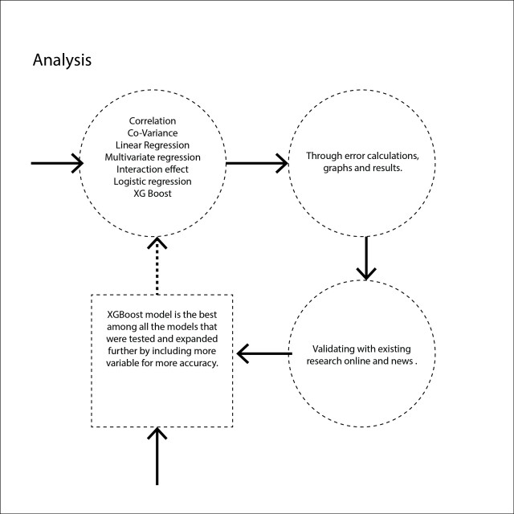

The most initial forms of predicting crimes was through GIS(Geographic Information system) Mapping. Experts were able to see patterns in crime occurences around the world. A 1998 study by Diana Ehlers and Gideon Pimstone used various factorsto predict crime rate per 100,000 in the United States. They concluded in their research that statistical methods such as regression analysis and correlation could be used to predict crime trends. Through them, policy makers can be given a “statistical glimpse of the future” (Ehlers, 1998).

Hence, I also tested various regression prediction models on the data that was collected to come up with the most accurate methology. The regression prediction models that were tested were based on the error values. Correlation and covariance were done to identify the factors on which the crime number per census tract was most dependent on. After that the following regression predictions were done :

```r
library(dplyr)
library(magrittr)
library(ggplot2)
library(coefplot)
library(plyr)
library(readr)
library(stringr)
# ## here we are going to find the root_file
 root <- rprojroot::find_rstudio_root_file()
# ## we are going to set the data file path here
 dataDir <- file.path(root, 'Data')

#TrainDF <- read.csv(file = "TrainDataFinal.csv", header = TRUE, sep = ",")
#TestDF <- read.csv("TestDataFinal.csv")

TrainDF <- read.csv(file = "TrainDataFinal1.csv", header = TRUE, sep = ",")
TestDF <- read.csv("TestDataFinal1.csv")
```

### 3.0.1. Correlation Analysis

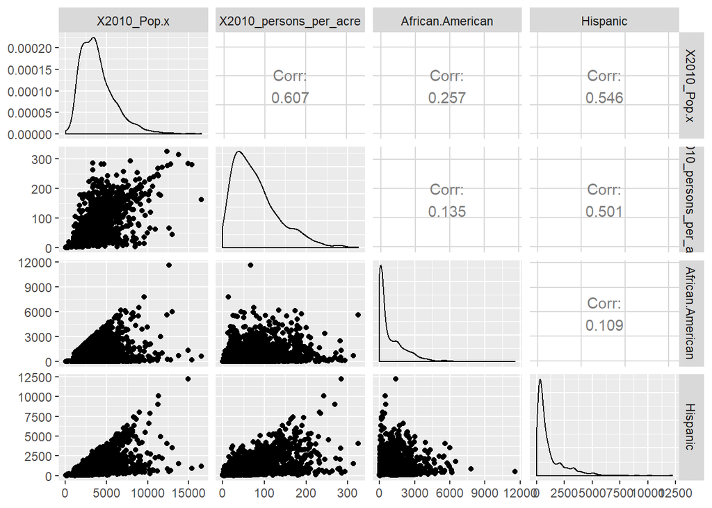

```r
cor(TrainDF$Crime_num, TrainDF$X2010_Pop.x) #high
cor(TrainDF$Crime_num, TrainDF$X2010_persons_per_acre)#high
cor(TrainDF$Crime_num, TrainDF$white)
cor(TrainDF$Crime_num, TrainDF$African.American) #high
cor(TrainDF$Crime_num, TrainDF$AI.and.Alaska)
cor(TrainDF$Crime_num, TrainDF$Asian)
cor(TrainDF$Crime_num, TrainDF$Hawai)
cor(TrainDF$Crime_num, TrainDF$Some.other.Race)
cor(TrainDF$Crime_num, TrainDF$Two.or.More)
cor(TrainDF$Crime_num, TrainDF$Hispanic) #high
cor(TrainDF$Crime_num, TrainDF$Vacant)
#cor(TrainDF$Crime_num, TrainDF$Total)
#income
cor(TrainDF$Crime_num, TrainDF$MHI)
#Education
cor(TrainDF$Crime_num, TrainDF$URate)
cor(TrainDF$Crime_num, TrainDF$HSPer)
#plotting for only top 4 : pop.x,pop_persons_per_acre, african.american, hispanic
GGally::ggpairs(TrainDF %>%dplyr::select(X2010_Pop.x,X2010_persons_per_acre , African.American, Hispanic))
```

# 3.0.2. Covariance Analysis

```r
#Covariance
cov(TrainDF$Crime_num, TrainDF$X2010_Pop.x) #positive high
cov(TrainDF$Crime_num, TrainDF$X2010_persons_per_acre)  #Positive low
cov(TrainDF$Crime_num, TrainDF$white) #negative high
cov(TrainDF$Crime_num, TrainDF$African.American) #positive high
cov(TrainDF$Crime_num, TrainDF$AI.and.Alaska) #positive low
cov(TrainDF$Crime_num, TrainDF$Asian) #negative high
cov(TrainDF$Crime_num, TrainDF$Hawai) #positive low
cov(TrainDF$Crime_num, TrainDF$Some.other.Race) #negative low
cov(TrainDF$Crime_num, TrainDF$Two.or.More) #positive low
cov(TrainDF$Crime_num, TrainDF$Hispanic) #positive high
cov(TrainDF$Crime_num, TrainDF$Vacant) #positive low
cov(TrainDF$Crime_num, TrainDF$Total) #positive high
cov(TrainDF$Crime_num, TrainDF$occupied) #positive high

#income
cov(TrainDF$Crime_num, TrainDF$MHI) #negative high
#Education
cov(TrainDF$Crime_num, TrainDF$URate) #positive, low
cov(TrainDF$Crime_num, TrainDF$HSPer) #positive, low
```

The covariance indicated similar trends as that of correlation analysis:

Independent variables such as population, african-american population, Hispanic population, total number of houses, Number of houses occupied have a high covariance value and hence have very high impact on positive change in crime rate.

### 3.0.3. Plotting high correlational values that were obtained from the above calculations

# Dependency of Crime of Population of the census tract

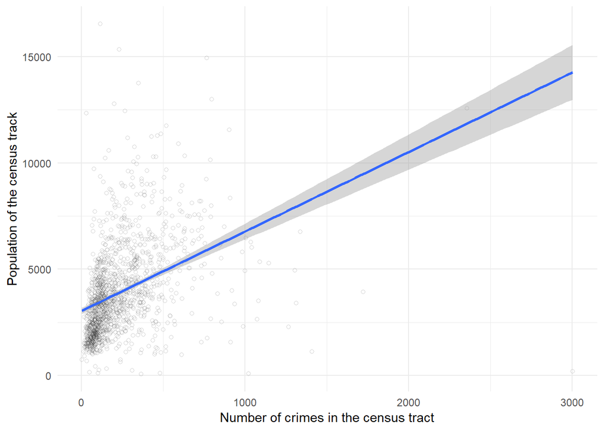

```r
ggplot(TrainDF, aes(x = Crime_num, y = X2010_Pop.x)) + geom_point(alpha = 1/6, shape = 1) + geom_smooth(method = 'lm') + theme_minimal() +
  ylab("Population of the census track") + xlab("Number of crimes in the census tract")
```

#Dependency of crime on Population per acre

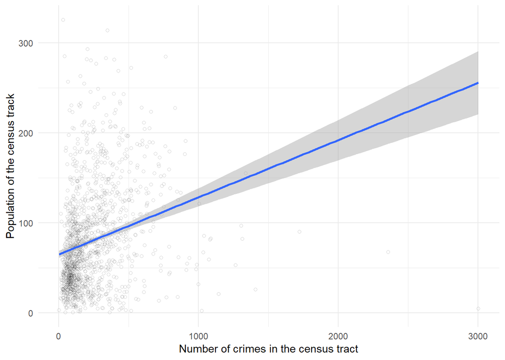

```r
ggplot(TrainDF, aes(x = Crime_num, y = X2010_persons_per_acre)) + geom_point(alpha = 1/6, shape = 1) + geom_smooth(method = 'lm') +
  theme_minimal() +ylab("Population of the census track") + xlab("Number of crimes in the census tract")
```

#Dependency of crime on African-American population

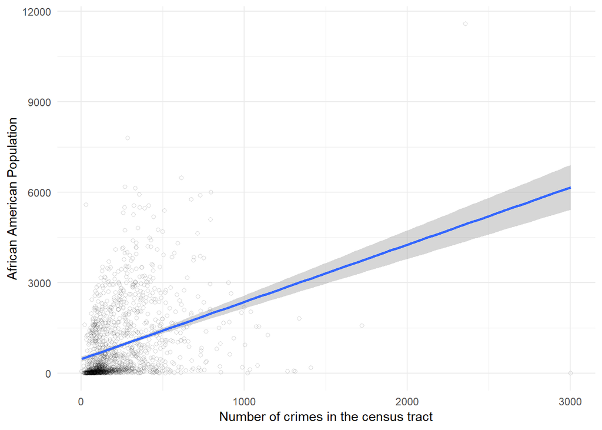

```r
ggplot(TrainDF, aes(x = Crime_num, y = African.American)) + geom_point(alpha = 1/6, shape = 1) + geom_smooth(method = 'lm') + theme_minimal() +
  ylab("African American Population") + xlab("Number of crimes in the census tract")
```

#Dependency of crime on Hispanic population

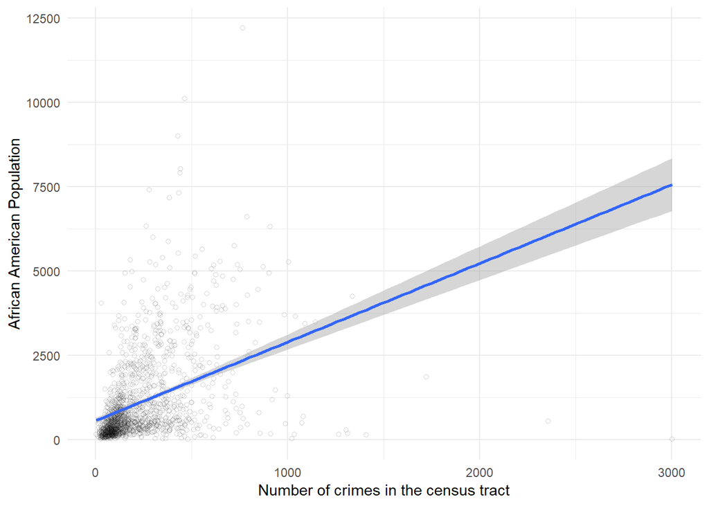

```r
ggplot(TrainDF, aes(x = Crime_num, y = Hispanic)) + geom_point(alpha = 1/6, shape = 1) + geom_smooth(method = 'lm') + theme_minimal() +
  ylab("African American Population") + xlab("Number of crimes in the census tract")
```

## 3.1.Linear regression model analysis

# Using Vacant Houses as Predictor variable

```r
VacLM <- lm(Crime_num ~ Vacant, data = TrainDF)
print(VacLM)
```

```
##
## Call:
## lm(formula = Crime_num ~ Vacant, data = TrainDF)
##
## Coefficients:
## (Intercept)       Vacant
##    190.8834       0.3581
```

```r
#calculating RMSE
sqrt(sum(residuals(VacLM)^2) / df.residual(VacLM))
```

```
## [1] 213.7075
```

## Using African American Population as Predictor Variable

```r
AALM <- lm(Crime_num ~ African.American, data = TrainDF)
print(AALM)
```

```
##
## Call:
## lm(formula = Crime_num ~ African.American, data = TrainDF)
##
## Coefficients:
##      (Intercept)  African.American
##        177.95986           0.06184
```

```r
#calculating RMSE
sqrt(sum(residuals(AALM)^2) / df.residual(AALM))
```

```
## [1] 205.3221
```

### Evaluating performance of both the models :

```r
#Doing outlier test for both the models
car::outlierTest(VacLM)
```

```
##       rstudent unadjusted p-value Bonferonni p
## 9    13.976693         9.0859e-42   1.3356e-38
## 1145 10.172185         1.5603e-23   2.2937e-20
## 81    7.062104         2.5238e-12   3.7100e-09
## 2     5.444550         6.0804e-08   8.9381e-05
## 71    5.068703         4.5149e-07   6.6368e-04
## 161   4.870695         1.2324e-06   1.8117e-03
## 160   4.812078         1.6477e-06   2.4221e-03
## 181   4.763940         2.0865e-06   3.0672e-03
## 403   4.348732         1.4637e-05   2.1517e-02
```

```r
car::outlierTest(AALM)
```

```
##       rstudent unadjusted p-value Bonferonni p
## 9    14.744242         5.5153e-46   8.1075e-43
## 1145  7.462289         1.4503e-13   2.1320e-10
## 81    7.167213         1.2082e-12   1.7761e-09
## 2     6.015336         2.2629e-09   3.3265e-06
## 161   5.566722         3.0820e-08   4.5305e-05
## 160   5.520575         3.9902e-08   5.8655e-05
## 181   5.334866         1.1062e-07   1.6261e-04
## 71    5.150400         2.9522e-07   4.3398e-04
## 403   4.351943         1.4427e-05   2.1208e-02
## 10    4.351154         1.4479e-05   2.1284e-02
```

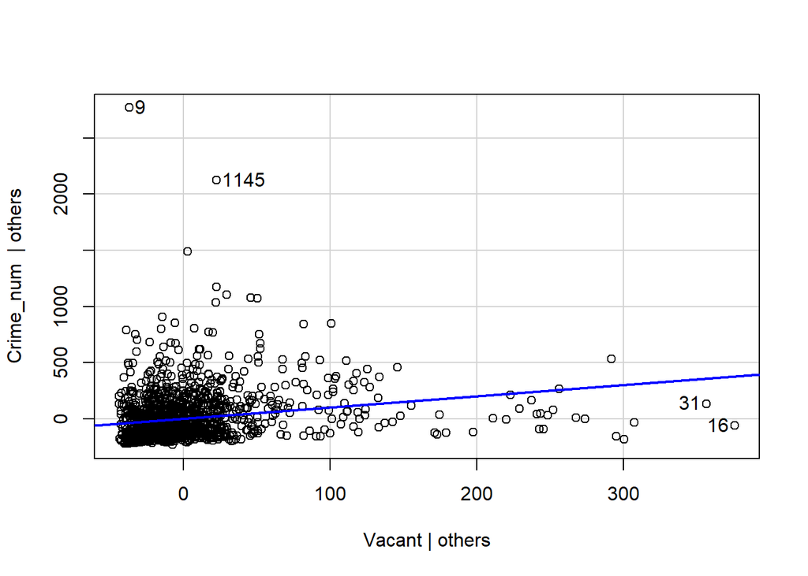

```r
#Doing leverage plots for both of them
car::leveragePlots(VacLM)
```

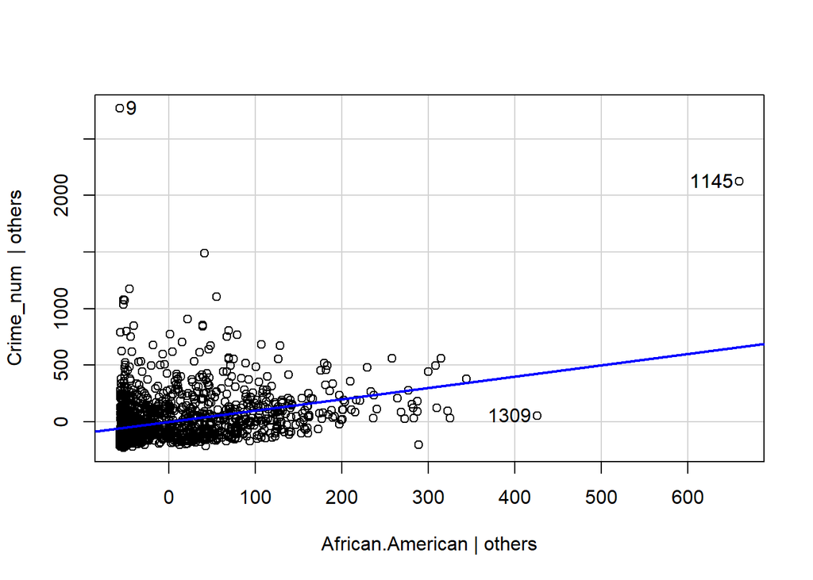

```r
car::leveragePlots(AALM)
```

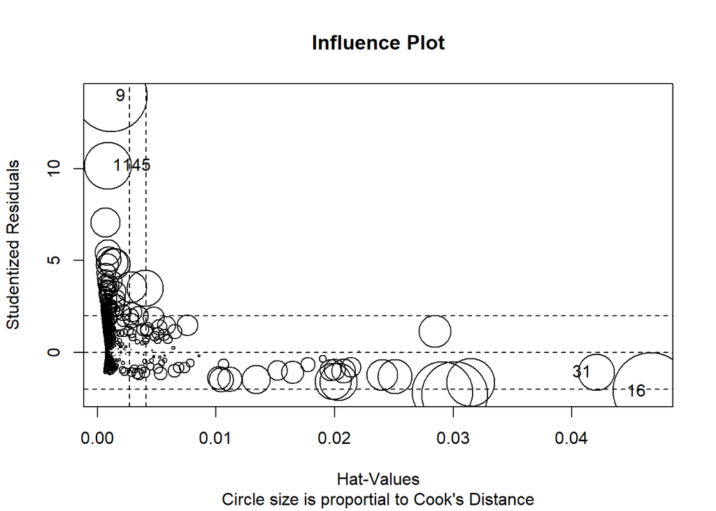

```
##        StudRes          Hat      CookD
## 9    13.976693 0.0011280212 0.09740706
## 16   -2.099517 0.0466720230 0.10765046
## 31   -1.062566 0.0420607449 0.02478466
## 1145 10.172185 0.0008431464 0.04080969
```

```r
#Influence plot for both the models
car::influencePlot(VacLM, id.method="identify", main="Influence Plot", sub="Circle size is proportial to Cook's Distance" )
```

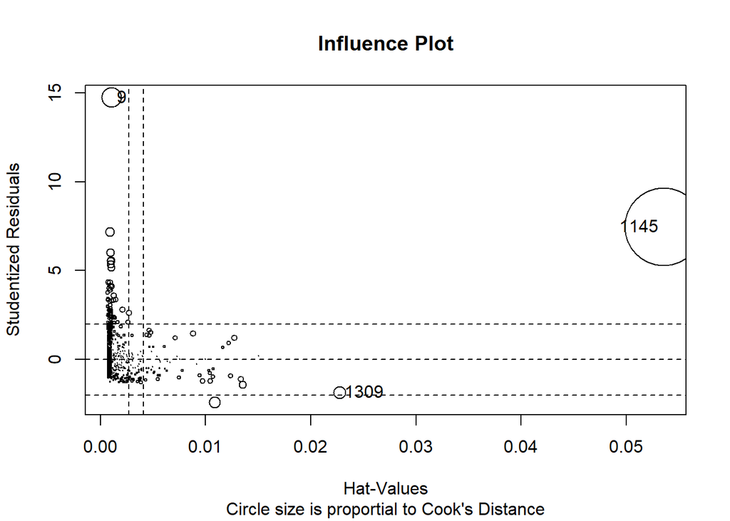

```
##        StudRes         Hat      CookD
## 9    14.744242 0.001067333 0.10121888
## 1145  7.462289 0.053561330 1.51910862
## 1309 -1.852711 0.022730757 0.03985345
```

```r
car::influencePlot(AALM, id.method="identify", main="Influence Plot", sub="Circle size is proportial to Cook's Distance" )
```

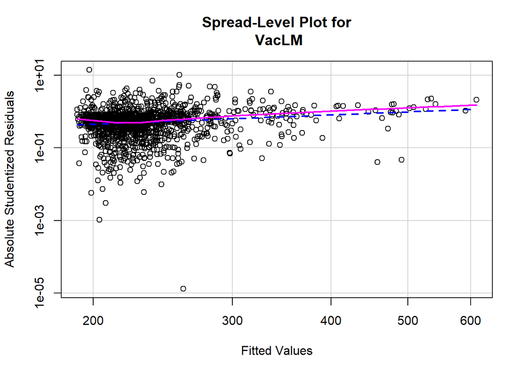

```
##
## Suggested power transformation:  0.1601914
```

```r
#plotting standardized residuals vs fitted values using spreadlevelplot
car::spreadLevelPlot(VacLM)
```

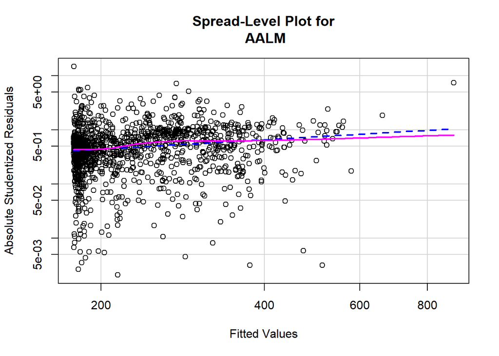

```
##
## Suggested power transformation:  0.4165626
```

```r
car::spreadLevelPlot(AALM)
```

As the errors were too high, the crime numbers were studied on the basis of Borough

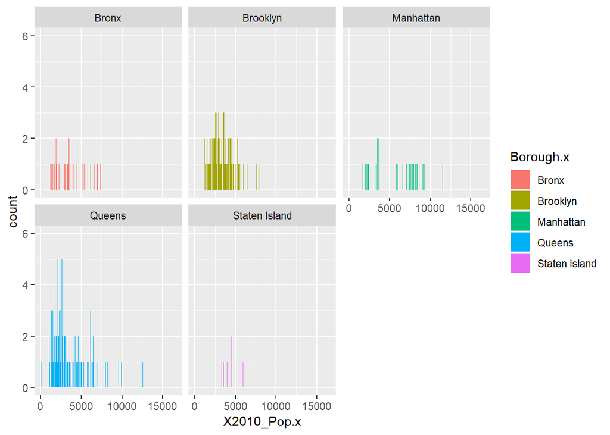

```r
#Plotting Population across boroughs
ggplot(TrainDF, aes(x = X2010_Pop.x, fill = Borough.x)) + geom_histogram(binwidth = 10) +
  facet_wrap(~ Borough.x)
```

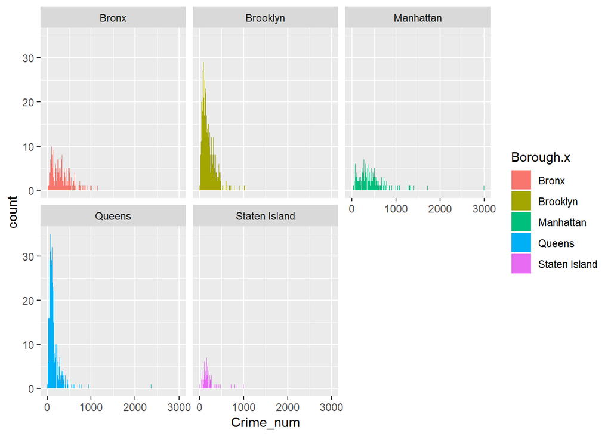

```r
#Plotting crime across boroughs
ggplot(TrainDF, aes(x = Crime_num, fill = Borough.x)) + geom_histogram(binwidth = 10) +
  facet_wrap(~ Borough.x)
```

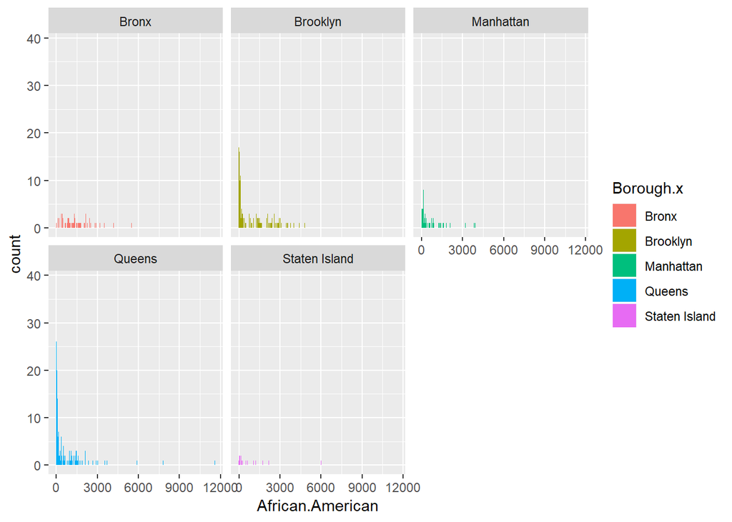

```r
#Plotting African.American population across boroughs
ggplot(TrainDF, aes(x = African.American, fill = Borough.x)) + geom_histogram(binwidth = 10) +
  facet_wrap(~ Borough.x)
```

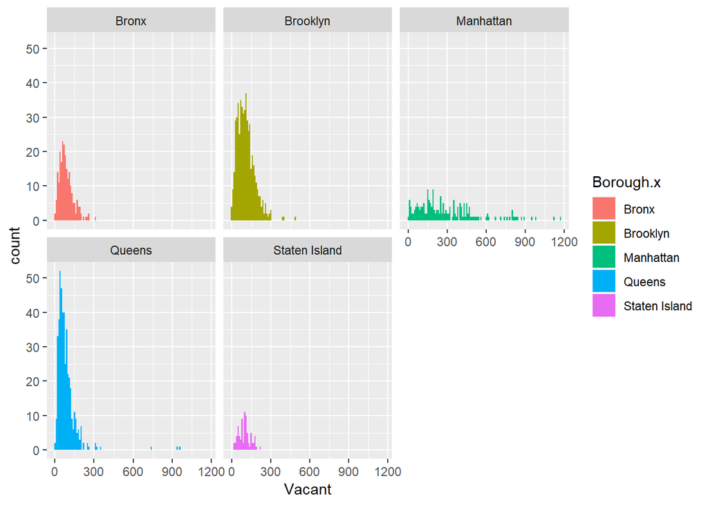

```r
#Plotting Vacant houses across boroughs
ggplot(TrainDF, aes(x = Vacant, fill = Borough.x)) + geom_histogram(binwidth = 10) +
  facet_wrap(~ Borough.x)
```

### Finding and removing outliers

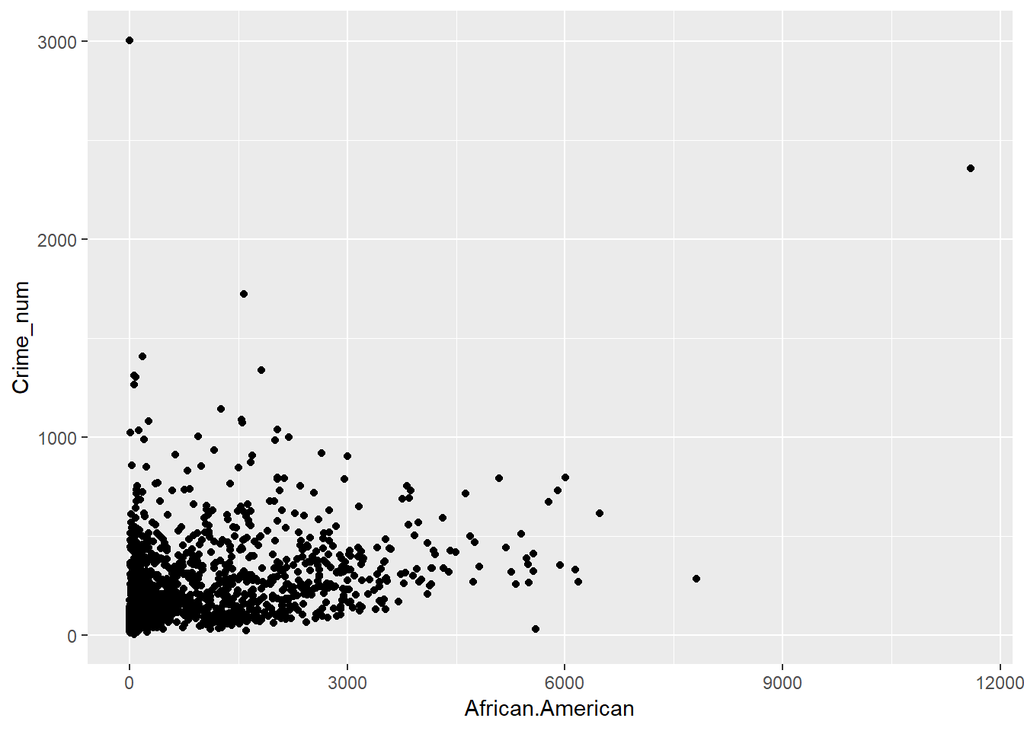

```r
#Crime_num ~ African.American+ Vacant + X2010_Pop.x + X2010_persons_per_acre +
#  Borough.x - white - Asian + Hispanic+ Total - MHI + URate - HSPer - occupied

ggplot(TrainDF, aes(African.American, Crime_num)) + geom_point()  ##x > 7500
```

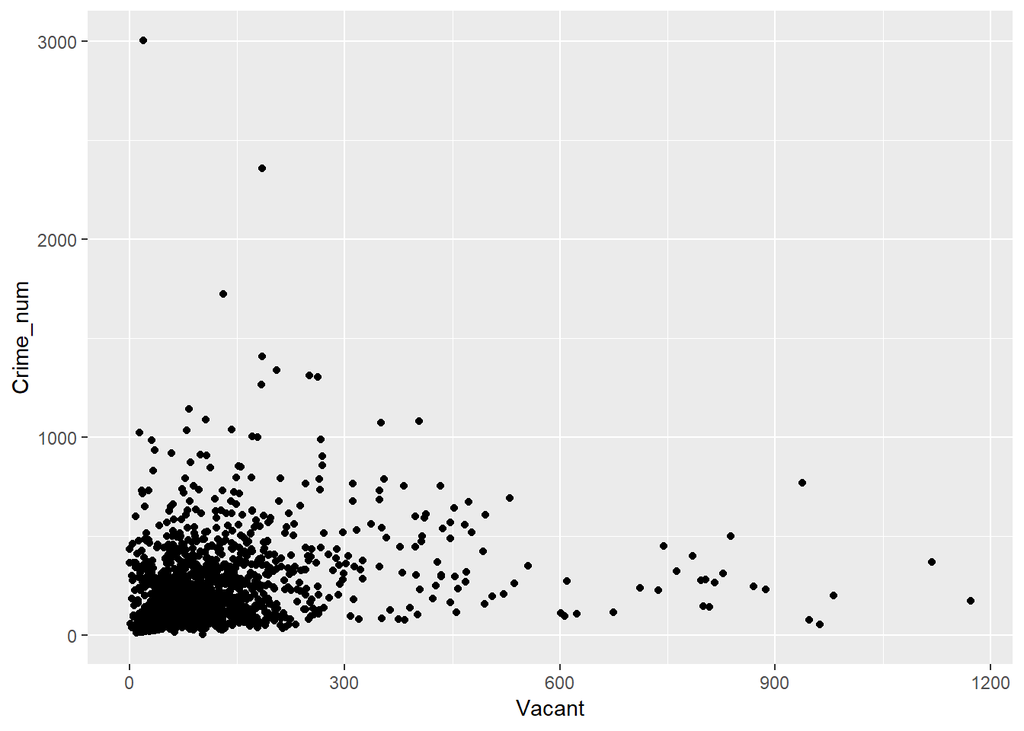

```r
ggplot(TrainDF, aes(Vacant, Crime_num)) + geom_point()  ##x > 1250
```

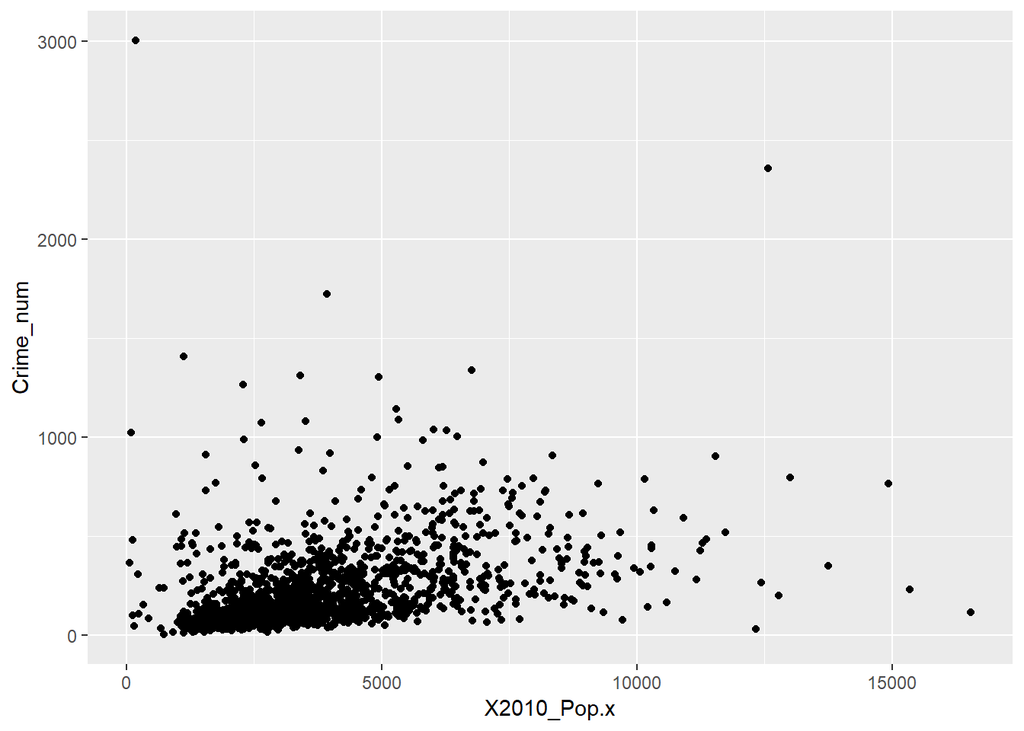

```r
ggplot(TrainDF, aes(X2010_Pop.x, Crime_num)) + geom_point()
```

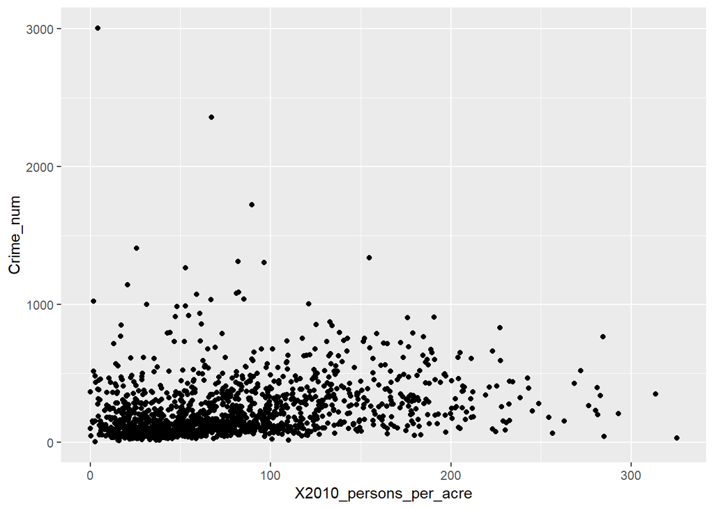

```r
ggplot(TrainDF, aes(X2010_persons_per_acre, Crime_num)) + geom_point()
```

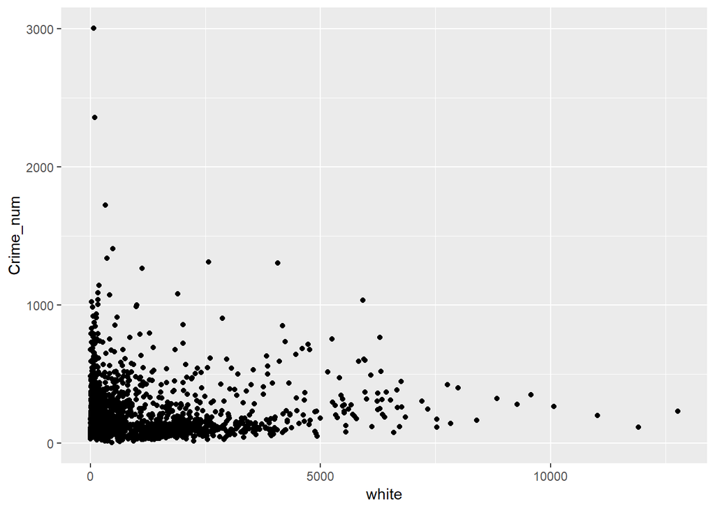

```r
ggplot(TrainDF, aes(white, Crime_num)) + geom_point()
```

```r
#removing outliers
TrainDF <-  TrainDF %>% filter(African.American < 7500)
TrainDF <-  TrainDF %>% filter(Vacant < 1250)
TrainDF <-  TrainDF %>% filter(X2010_Pop.x < 10000)
TrainDF <-  TrainDF %>% filter(X2010_persons_per_acre < 250)
```